# Multisequence_Alignments

## Multisequence Alignment (MSA)

Proteins are made up of sequences of amino acids chained together. Their amino acid sequence determines their structure and function. Finding proteins with similar sequences, or homologous proteins, is very useful in identifying the structures and functions of newly discovered proteins as well as identifying their ancestry. Below is an example of what a protein amino acid multisequence alignment may look like, taken from [2].

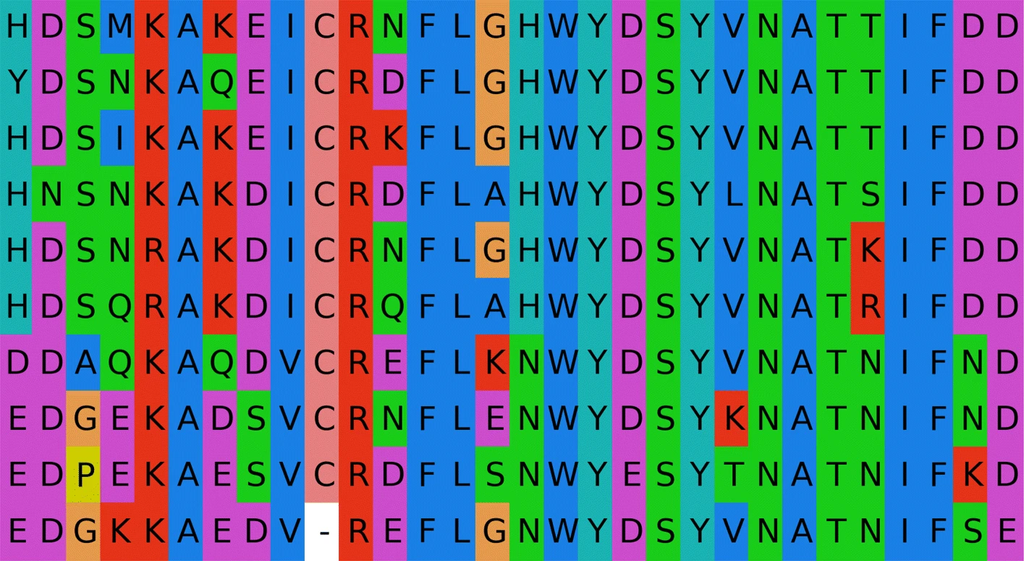

## Colab

This tutorial and the rest in this sequence can be done in Google colab. If you'd like to open this notebook in colab, you can use the following link.

## HH-suite

This tutorial will show you the basics of how to use hh-suite. hh-suite is an open source package for searching protein sequence alignments for homologous proteins. It is the current state of the art for building highly accurate multisequence alignments (MSA) from a single sequence or from MSAs.

References:

[1] Steinegger M, Meier M, Mirdita M, Vöhringer H, Haunsberger S J, and Söding J (2019) HH-suite3 for fast remote homology detection and deep protein annotation, BMC Bioinformatics, 473. doi: 10.1186/s12859-019-3019-7

[2] Kunzmann, P., Mayer, B.E. & Hamacher, K. Substitution matrix based color schemes for sequence alignment visualization. BMC Bioinformatics 21, 209 (2020). https://doi.org/10.1186/s12859-020-3526-6

## Setup

Let's start by importing the deepchem sequence_utils module and downloading a database to compare our query sequence to.

hh-suite provides a set of HMM databases that will work with the software, which you can find here: http://wwwuser.gwdg.de/~compbiol/data/hhsuite/databases/hhsuite_dbs

dbCAN is a good one for this tutorial because it is a relatively smaller download.

```python
from deepchem.utils import sequence_utils
```

```python
%%bash
mkdir hh
cd hh
mkdir databases; cd databases
wget http://wwwuser.gwdg.de/~compbiol/data/hhsuite/databases/hhsuite_dbs/dbCAN-fam-V9.tar.gz
tar xzvf dbCAN-fam-V9.tar.gz
```

```
dbCAN-fam-V9_a3m.ffdata
dbCAN-fam-V9_a3m.ffindex
dbCAN-fam-V9_hhm.ffdata
dbCAN-fam-V9_hhm.ffindex
dbCAN-fam-V9_cs219.ffdata
dbCAN-fam-V9_cs219.ffindex
dbCAN-fam-V9.md5sum
```

[output not shown]

[output cut: 460 more lines]

[output not shown]

## Using hhsearch

hhblits and hhsearch are the main functions in hhsuite which identify homologous proteins. They do this by calculating a profile hidden Markov model (HMM) from a given alignment and searching over a reference HMM proteome database using the Viterbi algorithm. Then the most similar HMMs are realigned and output to the user. To learn more, check out the original paper in the references above.

Run a function from hhsuite with no parameters to read its documentation.

```python
!hhsearch
```

```
HHsearch 3.3.0
Search a database of HMMs with a query alignment or query HMM
(c) The HH-suite development team
Steinegger M, Meier M, Mirdita M, Vöhringer H, Haunsberger S J, and Söding J (2019)
HH-suite3 for fast remote homology detection and deep protein annotation.
BMC Bioinformatics, doi:10.1186/s12859-019-3019-7

Usage: hhsearch -i query -d database [options]
 -i <file>      input/query multiple sequence alignment (a2m, a3m, FASTA) or HMM
Options:
 -d <name>      database name (e.g. uniprot20_29Feb2012)
                Multiple databases may be specified with '-d <db1> -d <db2> ...'
 -e     [0,1]   E-value cutoff for inclusion in result alignment (def=0.001)

Input alignment format:
 -M a2m         use A2M/A3M (default): upper case = Match; lower case = Insert;
               '-' = Delete; '.' = gaps aligned to inserts (may be omitted)
 -M first       use FASTA: columns with residue in 1st sequence are match states
 -M [0,100]     use FASTA: columns with fewer than X% gaps are match states
 -tags/-notags  do NOT / do neutralize His-, C-myc-, FLAG-tags, and trypsin
                recognition sequence to background distribution (def=-notags)

Output options:
 -o <file>      write results in standard format to file (default=<infile.hhr>)
 -oa3m <file>   write result MSA with significant matches in a3m format
 -blasttab <name> write result in tabular BLAST format (compatible to -m 8 or -outfmt 6 output)
                  1     2      3           4      5         6        7      8    9      10   11   12
                  query target #match/tLen alnLen #mismatch #gapOpen qstart qend tstart tend eval score
 -add_cons      generate consensus sequence as master sequence of query MSA (default=don't)
 -hide_cons     don't show consensus sequence in alignments (default=show)
 -hide_pred     don't show predicted 2ndary structure in alignments (default=show)
 -hide_dssp     don't show DSSP 2ndary structure in alignments (default=show)
 -show_ssconf   show confidences for predicted 2ndary structure in alignments
Filter options applied to query MSA, database MSAs, and result MSA
 -all           show all sequences in result MSA; do not filter result MSA
 -id   [0,100]  maximum pairwise sequence identity (def=90)
 -diff [0,inf[  filter MSAs by selecting most diverse set of sequences, keeping
                at least this many seqs in each MSA block of length 50
                Zero and non-numerical values turn off the filtering. (def=100)
 -cov  [0,100]  minimum coverage with master sequence (%) (def=0)
 -qid  [0,100]  minimum sequence identity with master sequence (%) (def=0)
 -qsc  [0,100]  minimum score per column with master sequence (default=-20.0)
 -neff [1,inf]  target diversity of multiple sequence alignment (default=off)
 -mark          do not filter out sequences marked by ">@"in their name line

HMM-HMM alignment options:
 -norealign          do NOT realign displayed hits with MAC algorithm (def=realign)
 -ovlp <int>         banded alignment: forbid <ovlp> largest diagonals |i-j| of DP matrix (def=0)
 -mact [0,1[         posterior prob threshold for MAC realignment controlling greedi-
                     ness at alignment ends: 0:global >0.1:local (default=0.35)
 -glob/-loc          use global/local alignment mode for searching/ranking (def=local)
Other options:
 -v <int>       verbose mode: 0:no screen output  1:only warnings  2: verbose (def=2)
 -cpu <int>     number of CPUs to use (for shared memory SMPs) (default=2)

An extended list of options can be obtained by calling 'hhblits -h all'

Example: hhsearch -i a.1.1.1.a3m -d scop70_1.71

Download databases from <http://wwwuser.gwdg.de/~compbiol/data/hhsuite/databases/hhsuite_dbs/>.
- 12:48:13.127 ERROR: Database is missing (see -d)!
```

Let's do an example. Say we have a protein which we want to compare to a MSA in order to identify any homologous regions. For this we can use hhsearch.

Now let's take some protein sequence and search through the dbCAN database to see if we can find any potential homologous regions. First we will specify the sequence and save it as a FASTA file or a3m file in order to be readable by hhsearch. I pulled this sequence from the example query.a3m in the hhsuite data directory.

```python
with open('protein.fasta', 'w') as f:
    f.write("""
>Uncharacterized bovine protein (Fragment)
--PAGGQCtgiWHLLTRPLRP--QGRLPGLRVKYVFLVWLGVFAGSWMAYTHYSSYAELCRGHICQVVICDQFRKGIISGSIC…
""")
```

Then we can call hhsearch, specifying the query sequence with the -i flag, the database to search through with -d, and the output with -o.

```python
from deepchem.utils import sequence_utils
dataset_path = 'protein.fasta'
data_dir = 'hh/databases'
results = sequence_utils.hhsearch(dataset_path,database='dbCAN-fam-V9', data_dir=data_dir)
```

```
- 12:48:13.301 INFO: Search results will be written to /home/tony/github/deepchem/examples/tutorials/protein.hhr

- 12:48:13.331 INFO: /home/tony/github/deepchem/examples/tutorials/protein.fasta is in A2M, A3M or FASTA format

- 12:48:13.331 WARNING: Input alignment /home/tony/github/deepchem/examples/tutorials/protein.fasta looks like aligned FASTA instead of A2M/A3M format. Consider using '-M first' or '-M 50'

- 12:48:13.331 INFO: NOTE: Use the '-add_cons' option to calculate a consensus sequence as first sequence of the alignment with hhconsensus or hhmake.

- 12:48:13.331 INFO: Searching 683 database HHMs without prefiltering

- 12:48:13.332 INFO: Iteration 1

- 12:48:13.420 INFO: Scoring 683 HMMs using HMM-HMM Viterbi alignment

- 12:48:13.460 INFO: Alternative alignment: 0

- 12:48:13.611 INFO: 683 alignments done

- 12:48:13.612 INFO: Alternative alignment: 1

- 12:48:13.625 INFO: 38 alignments done

- 12:48:13.625 INFO: Alternative alignment: 2

- 12:48:13.629 INFO: 3 alignments done

- 12:48:13.629 INFO: Alternative alignment: 3

- 12:48:13.655 INFO: Premerge done

- 12:48:13.656 INFO: Realigning 10 HMM-HMM alignments using Maximum Accuracy algorithm

- 12:48:13.692 INFO: 0 sequences belonging to 0 database HMMs found with an E-value < 0.001

- 12:48:13.692 INFO: Number of effective sequences of resulting query HMM: Neff = 1
```

```python
#open the results and print them
f = open("protein.hhr", "r")
print(f.read())
```

```
Query         Uncharacterized bovine protein (Fragment)
Match_columns 431
No_of_seqs    1 out of 1
Neff          1
Searched_HMMs 683
Date          Fri Feb 11 12:48:13 2022
Command       hhsearch -i /home/tony/github/deepchem/examples/tutorials/protein.fasta -d hh/databases/dbCAN-fam-V9 -oa3m /home/tony/github/deepchem/examples/tutorials/results.a3m -cpu 4 -e 0.001

 No Hit                             Prob E-value P-value  Score    SS Cols Query HMM  Template HMM
  1 ABJ15796.1|231-344|9.6e-33       8.2     2.9  0.0042   25.2   0.0   13  224-236    40-52  (116)
  2 lcl|consensus                    5.1     5.2  0.0076   17.1   0.0   14  182-195     1-14  (21)
  3 ABW08129.1|GT4|GT97||563-891     4.8     5.7  0.0084   26.6   0.0   46  104-150    93-140 (329)
  4 AEO62162.1|AA13||19-250          4.6       6  0.0087   25.5   0.0   18  330-347   139-156 (232)
  5 BAF49076.1|GH5_26.hmm|8.3e-11|   2.4      13    0.02   21.9   0.0   12  287-298    45-56  (141)
  6 BBD44721.1 Hypothetical protei   2.3      14    0.02   25.7   0.0   81  110-221   326-406 (552)
  7 AAU92474.1|CBM2|2-82|1.9e-23     2.3      14    0.02   19.1   0.0   19  222-240    13-33  (104)
  8 BAX82587.1 hypothetical protei   2.3      14   0.021   25.7   0.0   25  104-128   466-490 (656)
  9 AHE46274.1|GH13_13.hmm|1.6e-20   2.0      16   0.024   24.1   0.0   45  143-199    99-143 (393)
 10 ACF55060.1|GH13_13.hmm|2.5e-47   1.9      17   0.025   23.2   0.0   22  144-165    74-95  (330)

No 1
>ABJ15796.1|231-344|9.6e-33
Probab=8.16  E-value=2.9  Score=25.22  Aligned_cols=13  Identities=46%  Similarity=0.795  Sum_probs=10.2  Template_Neff=3.400

Q Uncharacterize  223 YCGDLYVTEGVPL  235 (430)
Q Consensus       224 ycgdlyvtegvpl  236 (431)
                      --||||.||||--
T Consensus        40 I~Gnlyi~eGVG~   52 (116)
T ABJ15796.1|231   40 INGNLYIAEGVGE   52 (116)
Confidence            3599999999853


No 2
>lcl|consensus
Probab=5.13  E-value=5.2  Score=17.13  Aligned_cols=14  Identities=29%  Similarity=0.437  Sum_probs=10.2  Template_Neff=4.300

Q Uncharacterize  181 DFNKDNRVSLAEAK  194 (430)
Q Consensus       182 dfnkdnrvslaeak  195 (431)
                      |.|.|++|+-.++-
T Consensus         1 DvN~DG~Vna~D~~   14 (21)
```

[output cut: 91 more lines]

```
T Consensus        99 ~~g~~Ri~EfR~MV~al-----------h~~GlrVv~DVVyNHT~~sg~-~~~SVlD  143 (393)
T AHE46274.1|GH1   99 PDGVARIKEFRAMVQAL-----------HAMGLRVVMDVVYNHTAASGQ-YDNSVLD  143 (393)
Confidence            34445589999998653           222235655555676655544 3345543


No 10
>ACF55060.1|GH13_13.hmm|2.5e-47|336-542
Probab=1.94  E-value=17  Score=23.24  Aligned_cols=22  Identities=23%  Similarity=0.371  Sum_probs=17.6  Template_Neff=4.500

Q Uncharacterize  143 SRGTSIKEFREMTLSFLKANLG  164 (430)
Q Consensus       144 srgtsikefremtlsflkanlg  165 (431)
                      +.-+.|+||++|...+=++.++
T Consensus        74 dp~~RI~E~K~mI~~lH~~GI~   95 (330)
T ACF55060.1|GH1   74 DPYGRIREFKQMIQALHDAGIR   95 (330)
Confidence            4456799999999988887765
```

Two files are output and saved to the dataset directory, results.hhr and results.a3m. results.hhr is the hhsuite results file, which is a summary of the results. results.a3m is the actual MSA file.

In the hhr file, the 'Prob' column describes the estimated probability of the query sequence being at least partially homologous to the template. Probabilities of 95% or more are nearly certain, and probabilities of 30% or more call for closer consideration. The E value tells you how many random matches with a better score would be expected if the searched database was unrelated to the query sequence. These results show that none of the sequences align well with our randomly chosen protein, which is to be expected because our query sequence was chosen at random.

Now let's check the results if we use a sequence that we know will align with something in the dbCAN database. I pulled this protein from the dockerin.faa file in dbCAN.

```python
with open('protein2.fasta', 'w') as f:
    f.write(""">dockerin,22,NCBI-Bacteria,gi|125972715|ref|YP_001036625.1|,162-245,0.033
SCADLNGDGKITSSDYNLLKRYILHLIDKFPIGNDETDEGINDGFNDETDEDINDSFIEANSKFAFDIFKQISKDEQGKNVFIS
""")

dataset_path = 'protein2.fasta'
sequence_utils.hhsearch(dataset_path,database='dbCAN-fam-V9', data_dir=data_dir)

#open the results and print them
f = open("protein2.hhr", "r")
print(f.read())
```

```
- 12:48:13.823 INFO: Search results will be written to /home/tony/github/deepchem/examples/tutorials/protein2.hhr

- 12:48:13.851 INFO: /home/tony/github/deepchem/examples/tutorials/protein2.fasta is in A2M, A3M or FASTA format

- 12:48:13.852 INFO: Searching 683 database HHMs without prefiltering

- 12:48:13.852 INFO: Iteration 1

- 12:48:13.873 INFO: Scoring 683 HMMs using HMM-HMM Viterbi alignment

- 12:48:13.913 INFO: Alternative alignment: 0

- 12:48:13.979 INFO: 683 alignments done

- 12:48:13.979 INFO: Alternative alignment: 1

- 12:48:13.982 INFO: 10 alignments done

- 12:48:13.982 INFO: Alternative alignment: 2

- 12:48:13.984 INFO: 3 alignments done

- 12:48:13.984 INFO: Alternative alignment: 3

- 12:48:13.986 INFO: 3 alignments done
```

```
Query         dockerin,22,NCBI-Bacteria,gi|125972715|ref|YP_001036625.1|,162-245,0.033
Match_columns 84
No_of_seqs    1 out of 1
Neff          1
Searched_HMMs 683
Date          Fri Feb 11 12:48:14 2022
Command       hhsearch -i /home/tony/github/deepchem/examples/tutorials/protein2.fasta -d hh/databases/dbCAN-fam-V9 -oa3m /home/tony/github/deepchem/examples/tutorials/results.a3m -cpu 4 -e 0.001

 No Hit                             Prob E-value P-value  Score    SS Cols Query HMM  Template HMM
  1 lcl|consensus                   97.0 5.9E-08 8.7E-11   43.5   0.0   21    4-24      1-21  (21)
  2 ABN51673.1|GH124|2-334|2.6e-21  92.5 0.00033 4.8E-07   45.5   0.0   68    1-75     21-88  (318)
  3 AAK20911.1|PL11|47-657|0        15.7     1.1  0.0017   27.6   0.0   14    1-14    329-342 (606)
  4 AGE62576.1|PL11_1.hmm|0|1-596   10.2     2.1  0.0031   26.0   0.0   13    1-13    118-130 (602)
  5 AAZ21803.1|GH103|26-328|1.7e-8   9.3     2.4  0.0035   22.4   0.0   10    4-13    175-184 (293)
  6 AGE62576.1|PL11_1.hmm|0|1-596    5.5     4.8   0.007   23.9   0.0   12    1-12    329-340 (602)
  7 AAK20911.1|PL11|47-657|0         5.5     4.8   0.007   23.8   0.0   13    1-13    118-130 (606)
  8 APU21542.1|PL11_2.hmm|1.4e-162   4.9     5.6  0.0082   23.5   0.0   14    2-15    318-331 (579)
  9 AAK20911.1|PL11|47-657|0         4.7     5.8  0.0084   23.4   0.0   10    3-12    184-193 (606)
 10 AGE62576.1|PL11_1.hmm|0|1-596    4.6       6  0.0088   23.3   0.0    7    4-10    185-191 (602)

No 1
>lcl|consensus
Probab=97.03  E-value=5.9e-08  Score=43.48  Aligned_cols=21  Identities=57%  Similarity=1.061  Sum_probs=20.1  Template_Neff=4.300

Q dockerin,22,NC    4 DLNGDGKITSSDYNLLKRYIL   24 (84)
Q Consensus         4 dlngdgkitssdynllkryil   24 (84)
                      |+|+||+|+..|+.++|||+|
T Consensus         1 DvN~DG~Vna~D~~~l~~~l~   21 (21)
T lcl|consensus_    1 DVNGDGKVNALDLALLKKYLL   21 (21)
Confidence            899999999999999999986


No 2
>ABN51673.1|GH124|2-334|2.6e-219
Probab=92.52  E-value=0.00033  Score=45.54  Aligned_cols=68  Identities=31%  Similarity=0.523  Sum_probs=51.6  Template_Neff=1.400

Q dockerin,22,NC    1 SCADLNGDGKITSSDYNLLKRYILHLIDKFPIGNDETDEGINDGFNDETDEDINDSFIEANSKFAFDIFKQISKD   75 (84)
Q Consensus         1 scadlngdgkitssdynllkryilhlidkfpigndetdegindgfndetdedindsfieanskfafdifkqiskd   75 (84)
                      ++||+||||+|+||||+|||| ||++|++||+++|||+|++|..      .-|+|.--.+-.++.....+.+.|.
T Consensus        21 v~GD~n~dgvv~isd~vl~k~-~l~~~a~~~a~~d~w~g~vN~d------d~I~D~d~~~~kryll~mir~~pk~   88 (318)
```

[output cut: 82 more lines]

```
                      -|+|+|||-.
T Consensus       184 yD~DGDGkAE  193 (606)
T AAK20911.1|PL1  184 YDFDGDGKAE  193 (606)
Confidence            3666666543


No 10
>AGE62576.1|PL11_1.hmm|0|1-596
Probab=4.58  E-value=6  Score=23.30  Aligned_cols=7  Identities=71%  Similarity=1.426  Sum_probs=0.0  Template_Neff=3.300

Q dockerin,22,NC    4 DLNGDGK   10 (84)
Q Consensus         4 dlngdgk   10 (84)
                      |||||||
T Consensus       185 D~DGDGk  191 (602)
T AGE62576.1|PL1  185 DFDGDGK  191 (602)
```

```
- 12:48:14.063 INFO: Premerge done

- 12:48:14.063 INFO: Realigning 10 HMM-HMM alignments using Maximum Accuracy algorithm

- 12:48:14.084 INFO: 4 sequences belonging to 4 database HMMs found with an E-value < 0.001

- 12:48:14.084 INFO: Number of effective sequences of resulting query HMM: Neff = 1.39047
```

As you can see, there are 2 sequences which are a match for our query sequence.

## Using hhblits

hhblits works in much the same way as hhsearch, but it is much faster and slightly less sensitive. This would be more suited to searching very large databases, or producing a MSA with multiple sequences instead of just one. Let's make use of that by using our query sequence to create an MSA. We could then use that MSA, with its family of proteins, to search a larger database for potential matches. This will be much more effective than searching a large database with a single sequence.

We will use the same dbCAN database. I will pull a glycoside hydrolase protein from UnipProt, so it will likely be related to some proteins in dbCAN, which has carbohydrate-active enzymes.

```python
!wget -O protein3.fasta https://www.uniprot.org/uniprot/G8M3C3.fasta

dataset_path = 'protein3.fasta'
sequence_utils.hhblits(dataset_path,database='dbCAN-fam-V9', data_dir=data_dir)

#open the results and print them
f = open("protein3.hhr", "r")
print(f.read())
```

```
--2022-02-11 12:48:14--  https://www.uniprot.org/uniprot/G8M3C3.fasta
Resolving www.uniprot.org (www.uniprot.org)... 193.62.193.81
Connecting to www.uniprot.org (www.uniprot.org)|193.62.193.81|:443... connected.
HTTP request sent, awaiting response... 200
Length: 897 [text/plain]
Saving to: ‘protein3.fasta’

protein3.fasta      100%[===================>]     897  --.-KB/s    in 0s

2022-02-11 12:48:15 (1.70 GB/s) - ‘protein3.fasta’ saved [897/897]
```

```
- 12:48:15.242 WARNING: Ignoring unknown option -n

- 12:48:15.242 WARNING: Ignoring unknown option 2

- 12:48:15.242 INFO: Search results will be written to /home/tony/github/deepchem/examples/tutorials/protein3.hhr

- 12:48:15.270 INFO: /home/tony/github/deepchem/examples/tutorials/protein3.fasta is in A2M, A3M or FASTA format

- 12:48:15.271 INFO: Searching 683 database HHMs without prefiltering

- 12:48:15.271 INFO: Iteration 1

- 12:48:15.424 INFO: Scoring 683 HMMs using HMM-HMM Viterbi alignment

- 12:48:15.465 INFO: Alternative alignment: 0

- 12:48:15.658 INFO: 683 alignments done

- 12:48:15.659 INFO: Alternative alignment: 1

- 12:48:15.697 INFO: 92 alignments done

- 12:48:15.697 INFO: Alternative alignment: 2

- 12:48:15.710 INFO: 7 alignments done

- 12:48:15.710 INFO: Alternative alignment: 3
```

```
Query         tr|G8M3C3|G8M3C3_HUNCD Dockerin-like protein OS=Hungateiclostridium clariflavum (strain DSM 19732 / NBRC 101661 / EBR45) OX=720554 GN=Clocl_4007 PE=4 SV=1
Match_columns 728
No_of_seqs    1 out of 1
Neff          1
Searched_HMMs 683
Date          Fri Feb 11 12:48:16 2022
Command       hhsearch -i /home/tony/github/deepchem/examples/tutorials/protein3.fasta -d hh/databases/dbCAN-fam-V9 -oa3m /home/tony/github/deepchem/examples/tutorials/results.a3m -cpu 4 -n 2 -e 0.001

 No Hit                             Prob E-value P-value  Score    SS Cols Query HMM  Template HMM
  1 AAA91086.1|GH48|150-238|4.7e-1 100.0  7E-195  1E-197 1475.1   0.0  608   31-644     1-619 (620)
  2 lcl|consensus                   91.8 0.00051 7.4E-07   37.5   0.0   20  668-687     1-20  (21)
  3 ABN51673.1|GH124|2-334|2.6e-21  52.5   0.096 0.00014   40.1   0.0   66  663-728    19-85  (318)
  4 CAR68154.1|GH88|62-388|4.9e-13  10.5       2   0.003   30.7   0.0   43  421-463   181-223 (329)
  5 ACY49347.1|GH105|46-385|1.1e-1   6.4       4  0.0058   28.2   0.0   60  324-383   169-228 (329)
  6 QGI59602.1|GH16_22|78-291        5.4     4.9  0.0072   27.6   0.0   10  391-400    33-42  (224)
  7 QGI59602.1|GH16_22|78-291        5.3       5  0.0073   27.5   0.0   18  581-598   204-221 (224)
  8 AQA16748.1|GH5_51.hmm|7.4e-189   4.9     5.5  0.0081   28.6   0.0   37  644-680   253-291 (351)
  9 CCF60459.1|GH5_12.hmm|1.2e-238   3.3     9.1   0.013   28.3   0.0   27  357-383   298-324 (541)
 10 ACI55886.1|GH25|58-236|2.7e-60   3.0      10   0.015   22.2   0.0   41  594-634    18-61  (174)

No 1
>AAA91086.1|GH48|150-238|4.7e-10
Probab=100.00  E-value=6.7e-195  Score=1475.15  Aligned_cols=608  Identities=60%  Similarity=1.105  Sum_probs=604.0  Template_Neff=2.700

Q tr|G8M3C3|G8M3   31 FKDRFNYMYNKIHDPANGYFDSEGIPYHSVETLCVEAPDYGHESTSEAASYYAWLEAVNGKLNGKWSGLTEAWNVVEKYF  110 (728)
Q Consensus        31 fkdrfnymynkihdpangyfdsegipyhsvetlcveapdyghestseaasyyawleavngklngkwsglteawnvvekyf  110 (728)
                      |.||||+||+|||||+|||||++||||||||||||||||||||||||||||++|||||||+|||||++|++||++||+||
T Consensus         1 Y~~rFl~lY~kI~dp~nGYFS~~GiPYHsvETlivEAPDyGHeTTSEA~SY~~WLeAmyg~itgd~s~~~~AW~~mE~y~   80 (620)
T AAA91086.1|GH4    1 YKQRFLELYNKIHDPANGYFSPEGIPYHSVETLIVEAPDYGHETTSEAYSYYVWLEAMYGKITGDWSGFNKAWDTMEKYI   80 (620)
Confidence            78999999999999999999999999999999999999999999999999999999999999999999999999999999


Q tr|G8M3C3|G8M3  111 IPSESIQKGMNRYNPSSPAGYADEFPLPDDYPAQIQSNVTVGQDPIHQELVSAYNTYAMYGMHWLVDVDNWYGYGT----  186 (728)
Q Consensus       111 ipsesiqkgmnrynpsspagyadefplpddypaqiqsnvtvgqdpihqelvsayntyamygmhwlvdvdnwygygt----  186 (728)
                      ||++++||+|+.|||++|||||||+++|++||++|+++++||+|||++||+++||+++||+||||||||||||||+
T Consensus        81 IP~~~~Qp~~~~Ynp~~pAtya~E~~~P~~YPs~l~~~~~vG~DPi~~eL~saYgt~~iY~MHWLlDVDN~YGfG~~g~~  160 (620)
T AAA91086.1|GH4   81 IPSHQDQPTMSSYNPSSPATYAPEYDTPSQYPSQLDFNVPVGQDPIANELKSAYGTDDIYGMHWLLDVDNWYGFGNLGDG  160 (620)
Confidence            9999999999999999999999999999999999999999999999999999999999999999999999999999


```

[output cut: 139 more lines]

```
T Consensus       298 np~G~saWl~~~~~~d~~ygw~r~~~w  324 (541)
T CCF60459.1|GH5  298 NPKGVSAWLSGEERDDKKYGWKRDPEW  324 (541)
Confidence            345667777777777666777655443


No 10
>ACI55886.1|GH25|58-236|2.7e-60
Probab=3.03  E-value=10  Score=22.20  Aligned_cols=41  Identities=20%  Similarity=0.114  Sum_probs=30.1  Template_Neff=7.700

Q tr|G8M3C3|G8M3  594 QGVKFIDIRSKY---KDDPWYEGLKKQAEQGIPFEYTLHRFWHQ  634 (728)
Q Consensus       594 qgvkfidirsky---kddpwyeglkkqaeqgipfeytlhrfwhq  634 (728)
                      +|..|.-||.-+   -.||.|..=-+....-..|.=.||-+.+.
T Consensus        18 ~gi~Fv~ikateG~~~~D~~f~~n~~~a~~aGl~~G~Yhf~~~~   61 (174)
T ACI55886.1|GH2   18 SGVDFVIIKATEGTSYVDPYFASNWAGARAAGLPVGAYHFARPC   61 (174)
Confidence            389999999765   36888876555555556788889988854
```

```
- 12:48:16.066 INFO: Premerge done

- 12:48:16.066 INFO: Realigning 10 HMM-HMM alignments using Maximum Accuracy algorithm

- 12:48:16.115 INFO: 4 sequences belonging to 4 database HMMs found with an E-value < 0.001

- 12:48:16.115 INFO: Number of effective sequences of resulting query HMM: Neff = 2.41642
```

## Other hh-suite functions

hhsuite contains other functions which may be useful if you are working with MSA or HMMs. For more detailed information, see the documentation at https://github.com/soedinglab/hh-suite/wiki

hhmake: Build an HMM from an input MSA

hhfilter: Filter an MSA by max sequence identity, coverage, and other criteria

hhalign: Calculate pairwise alignments etc. for two HMMs/MSAs

hhconsensus: Calculate the consensus sequence for an A3M/FASTA input file

reformat.pl: Reformat one or many MSAs

addss.pl: Add PSIPRED predicted secondary structure to an MSA or HHM file

hhmakemodel.pl: Generate MSAs or coarse 3D models from HHsearch or HHblits results

hhmakemodel.py: Generates coarse 3D models from HHsearch or HHblits results and modifies cif files such that they are compatible with MODELLER

hhsuitedb.py: Build HHsuite database with prefiltering, packed MSA/HMM, and index files

splitfasta.pl: Split a multiple-sequence FASTA file into multiple single-sequence files

renumberpdb.pl: Generate PDB file with indices renumbered to match input sequence indices

HHPaths.pm: Configuration file with paths to the PDB, BLAST, PSIPRED etc. mergeali.pl: Merge MSAs in A3M format according to an MSA of their seed sequences

pdb2fasta.pl: Generate FASTA sequence file from SEQRES records of globbed pdb files

cif2fasta.py: Generate a FASTA sequence from the pdbx_seq_one_letter_code entry of the entity_poly of globbed cif files

pdbfilter.pl: Generate representative set of PDB/SCOP sequences from pdb2fasta.pl output

pdbfilter.py: Generate representative set of PDB/SCOP sequences from cif2fasta.py output

# Congratulations! Time to join the Community!

Congratulations on completing this tutorial notebook! If you enjoyed working through the tutorial, and want to continue working with DeepChem, we encourage you to finish the rest of the tutorials in this series. You can also help the DeepChem community in the following ways:

## Star DeepChem on [GitHub](https://github.com/deepchem/deepchem)

This helps build awareness of the DeepChem project and the tools for open source drug discovery that we're trying to build.

## Join the DeepChem Gitter

The DeepChem [Gitter](https://gitter.im/deepchem/Lobby) hosts a number of scientists, developers, and enthusiasts interested in deep learning for the life sciences. Join the conversation!